# Project B: QuantEcon Community Library

## SCE Working Group 1 · first full-group meeting · 1 October 2026 Project B **Community Library**

[figure not shown]

A community library of baseline economic models.

Matt McKay · QuantEcon · co-chair

## What? Same model. Multiple tools. **Side by side.** Built together.

## What? · three goals Three goals, each built on the last

Start

### Discovery

One place to find every toolkit.

Next

### Comparison

One model, many solutions, discussed openly.

Then

### Project A corpus

Real cases for the semantics work.

## How?

Community first, corpus second.

## How? · step 1 of 3 Start with a directory

Directory

Model families

Project A corpus

+ Your toolkit

Toolkit

Language

What it does

Repository

One place to discover every toolkit.

Proposed first step

## How? · step 2 of 3 One model, many solutions, one conversation

Directory

Model families

Project A corpus

Buffer-stock saving Shared description

HARK · EGM

PR #5 · open

+ Your solution

+ Another method

Discussed openly · never ranked

## How? · step 3 of 3 A corpus for Project A

Directory

Model families

Project A corpus

Many solutions

one described model

Settings recorded

method grid conventions

Project A

evaluates semantics and approaches

## Future

A designed community space.

## Future · prototype Your notebooks, published by model family

Buffer-stock saving · family pagePrototype

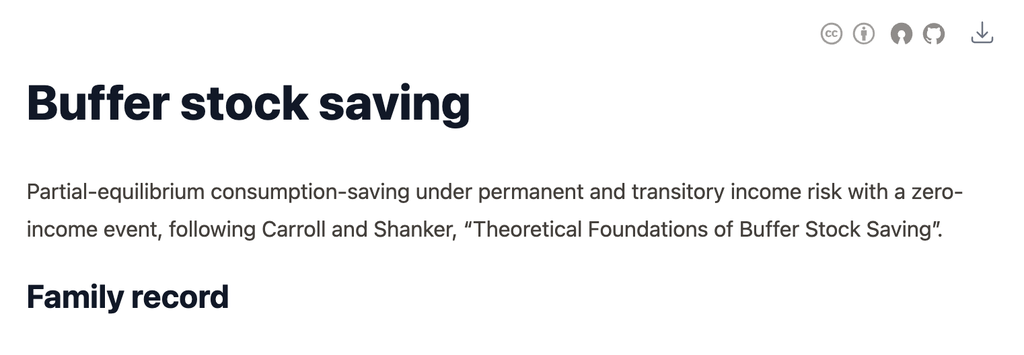

Comparison · test pairPrototype

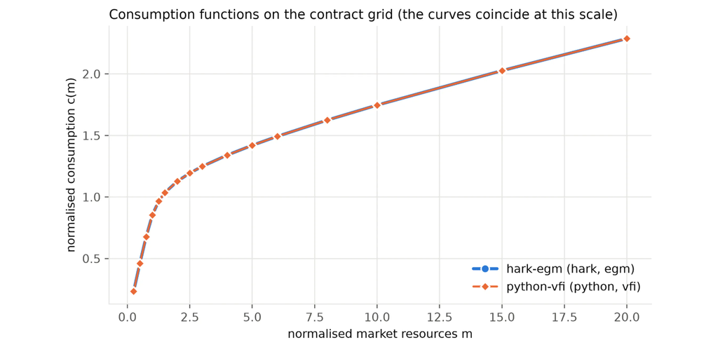

Family page One home per model family

Comparison Two methods agree,  
never ranked

## Future · we propose A space the community shapes

### Showcases

Each project’s own choice of problem.

### Discussion

A thread beside every solution.

### Review

Ideally from another toolkit, credited on the page.

## The working group *fosters* the library

Directory Register your toolkit A short GitHub form. Nothing binding.

Model families Submit a solution Buffer-stock saving first, or propose your model.

Forms: github.com/econ-ark/sce-wg-1/issues/new/choose

[figure not shown]

Our mission [quantecon.org/infrastructure ↗](https://quantecon.org/infrastructure/)

QuantEcon advances open-source software and open science in economics — **freely available, high-quality computational tools and educational resources** as a public good for the global economics community.